# Offline GBC PheWAS mediation follow-up

Author

Gibran Hemani

Published

October 9, 2026

## Inventory and local inputs

The report rebuilds from saved associations, with remote extraction, downloads and package installation disabled. Old regional `exp_sets`, reduced `outdat`, old MR results and knitr result caches are not inputs to the corrected analysis.

There are **33 unique pairs**, **26 mediators** and **6 retained target SNPs**. The saved follow-up had 53 rows; repeated rows do not add comparisons. The original PheWAS covered eight lead SNPs. The two without retained saved follow-up associations are accounted for below; the saved data do not establish why they were not retained.

| target_snp | retained_pairs | followup_status | gbc_pval |
| --- | --- | --- | --- |
| rs67274221 | 2 | Retained saved follow-up | 0 |
| rs35604230 | 17 | Retained saved follow-up | 0 |
| rs60541816 | 6 | Retained saved follow-up | 0 |
| rs6733452 | 5 | Retained saved follow-up | 0 |
| rs2312959 | 0 | No retained saved SNP-mediator association; not analysed | 0 |
| rs15734 | 2 | Retained saved follow-up | 0 |
| rs2131242 | 1 | Retained saved follow-up | 0 |
| rs77155094 | 0 | No retained saved SNP-mediator association; not analysed | 0 |

These GBC lead variants are not generally weak associations: seven of eight have P < 5e-8; rs2131242 is below that significance threshold (saved outcome P = 9.9e-07). The original report quoted approximately 4.81e-7; the saved outcome association used here differs, and both values are below genome-wide significance. Genome-wide significance alone does not establish instrument validity.

## Exact-hit comparisons

Every target estimate uses exactly its named SNP in `int_chd`, harmonised with the full saved GBC outcome `outgwasf`. The comparator is rebuilt from that mediator’s saved instruments, excluding **all eight known GBC lead SNPs and their ±1 Mb regions**, inclusive, before outcome matching and harmonisation. This includes original leads without retained mediator follow-up pairs. Each mediator has one shared comparator estimate and instrument set, reused for every exact-hit Q test, pooled MR and decomposition. Known outcome hits cannot become comparator instruments for another exact hit. The figure shows one panel per mediator, with every retained exact hit and a single other-SNP estimate. Saved coordinate mismatches and missing instrument coordinates are excluded. A geographic window does not prove LD independence; there is no fetched LD reference or genome-build conversion. The supplement includes ±2 Mb and additional chromosome 6 25–34 Mb MHC exclusions where relevant.

TwoSampleMR action 3 removes every A/T and C/G palindrome regardless of frequency. Non-palindromic strand complements and allele reversals are harmonised; incompatible alleles, unvalidated proxies, conflicting duplicates and invalid SEs yield explicit unavailability. The recorded target effect allele orients both target associations. A usable total GBC association may remain when a mediator component is unusable.

The exact target uses a Wald ratio. Comparators use a Wald ratio for one instrument or IVW with multiplicative random effects for multiple instruments. Conventional first-order ratio SEs treat exposure effects as fixed; beta/SE-derived F statistics are available in the CSV, and measure strength rather than validity or independence. Decomposition below propagates uncertainty in both multiplicands. Specific mediator transformations/units were not preserved: effects use **saved GWAS units, specific unit unavailable**, with target and comparator matched by mediator GWAS ID. Comparison panels use their own scales; magnitudes across mediators are not comparable.

| SNP | mediator | EA | exact_CI | other_CI | n | Q_P | Q_BH_P | interpretation |
| --- | --- | --- | --- | --- | --- | --- | --- | --- |
| rs35604230 | Hematocrit | A | 21.7 [14.2, 29.2] | 0.0327 [-0.22, 0.286] | 366 | 1.4e-08 | 1.9e-08 | Incompatible with common-effect model (BH < 0.05) |
| rs35604230 | Mean platelet volume | A | 7.82 [5.12, 10.5] | -0.0397 [-0.185, 0.106] | 401 | 1.2e-08 | 1.9e-08 | Incompatible with common-effect model (BH < 0.05) |
| rs67274221 | Mean platelet volume | A | -2.88 [-3.74, -2.03] | -0.0397 [-0.185, 0.106] | 401 | 1.2e-10 | 4.9e-10 | Incompatible with common-effect model (BH < 0.05) |
| rs35604230 | Eosinophil counts | A | 18.7 [12.2, 25.1] | 0.0395 [-0.17, 0.249] | 327 | 1.5e-08 | 1.9e-08 | Incompatible with common-effect model (BH < 0.05) |
| rs15734 | Platelet count | G | -17.2 [-22.7, -11.6] | 0.211 [0.035, 0.387] | 405 | 8.3e-10 | 2.3e-09 | Incompatible with common-effect model (BH < 0.05) |
| rs35604230 | Platelet count | A | -17.3 [-23.2, -11.3] | 0.211 [0.035, 0.387] | 405 | 9e-09 | 1.9e-08 | Incompatible with common-effect model (BH < 0.05) |
| rs67274221 | Platelet count | A | 4.73 [3.33, 6.13] | 0.211 [0.035, 0.387] | 405 | 3.3e-10 | 1.1e-09 | Incompatible with common-effect model (BH < 0.05) |
| rs60541816 | Low density lipoprotein cholesterol levels | A | 27.3 [20.8, 33.7] | 0.0543 [-0.149, 0.258] | 258 | 1.3e-16 | 1.5e-15 | Incompatible with common-effect model (BH < 0.05) |
| rs6733452 | Low density lipoprotein cholesterol levels | A | -7.49 [-9.77, -5.21] | 0.0543 [-0.149, 0.258] | 258 | 1.1e-10 | 4.9e-10 | Incompatible with common-effect model (BH < 0.05) |
| rs35604230 | Sex hormone-binding globulin levels adjusted for BMI | A | -44 [-59.2, -28.9] | -0.318 [-0.751, 0.115] | 335 | 1.7e-08 | 2.1e-08 | Incompatible with common-effect model (BH < 0.05) |
| rs35604230 | Urate levels (UKB data field 30880) | A | -22.4 [-30.1, -14.7] | -0.184 [-0.522, 0.154] | 241 | 1.8e-08 | 2.1e-08 | Incompatible with common-effect model (BH < 0.05) |
| rs35604230 | Type 1 diabetes | A | -0.692 [-0.93, -0.453] | -0.0168 [-0.119, 0.0857] | 65 | 3.5e-07 | 3.7e-07 | Incompatible with common-effect model (BH < 0.05) |
| rs2131242 | Cholelithiasis | A | -3.06 [-4.25, -1.87] | 0.532 [0.17, 0.893] | 34 | 1.6e-08 | 2e-08 | Incompatible with common-effect model (BH < 0.05) |
| rs60541816 | Cholelithiasis | A | 3.94 [3.01, 4.87] | 0.532 [0.17, 0.893] | 34 | 2.2e-11 | 1.5e-10 | Incompatible with common-effect model (BH < 0.05) |
| rs6733452 | Cholelithiasis | A | 1.21 [0.838, 1.57] | 0.532 [0.17, 0.893] | 34 | 0.01 | 0.01 | Incompatible with common-effect model (BH < 0.05) |
| rs60541816 | Alanine aminotransferase levels | A | 16.1 [12.3, 19.9] | 0.366 [-0.0383, 0.771] | 159 | 7.5e-16 | 6.2e-15 | Incompatible with common-effect model (BH < 0.05) |
| rs60541816 | Aspartate aminotransferase levels | A | 30.4 [23.2, 37.6] | 0.0448 [-0.334, 0.424] | 204 | 1.3e-16 | 1.5e-15 | Incompatible with common-effect model (BH < 0.05) |
| rs6733452 | Total cholesterol levels | A | -10 [-13.1, -6.96] | 0.106 [-0.203, 0.415] | 144 | 1e-10 | 4.9e-10 | Incompatible with common-effect model (BH < 0.05) |
| rs60541816 | Height | A | -39.1 [-48.3, -29.9] | -0.118 [-0.287, 0.0507] | 713 | 1.4e-16 | 1.5e-15 | Incompatible with common-effect model (BH < 0.05) |
| rs35604230 | Thyroid problem (not cancer) | A | -107 [-144, -69.9] | 0.548 [-1.52, 2.62] | 117 | 1.2e-08 | 1.9e-08 | Incompatible with common-effect model (BH < 0.05) |
| rs35604230 | Diabetic retinopathy (DM_RETINOPATHY) | A | -2.63 [-3.54, -1.72] | 0.0066 [-0.287, 0.301] | 7 | 6e-08 | 6.6e-08 | Incompatible with common-effect model (BH < 0.05) |
| rs60541816 | Disorders of gallbladder, biliary tract and pancreas | A | 3.14 [2.4, 3.89] | 0.612 [0.208, 1.02] | 17 | 4.5e-09 | 1.1e-08 | Incompatible with common-effect model (BH < 0.05) |
| rs6733452 | Disorders of gallbladder, biliary tract and pancreas | A | 1.41 [0.982, 1.84] | 0.612 [0.208, 1.02] | 17 | 0.0079 | 0.0082 | Incompatible with common-effect model (BH < 0.05) |
| rs35604230 | Rheumatoid arthritis | A | -1.34 [-1.8, -0.878] | 0.164 [0.0421, 0.286] | 33 | 7e-10 | 2.1e-09 | Incompatible with common-effect model (BH < 0.05) |
| rs35604230 | systolic blood pressure | A | 1.09 [0.716, 1.47] | -0.00278 [-0.0207, 0.0151] | 377 | 1.3e-08 | 1.9e-08 | Incompatible with common-effect model (BH < 0.05) |
| rs35604230 | diastolic blood pressure | A | 2.07 [1.36, 2.79] | 0.0376 [0.0109, 0.0644] | 386 | 2.5e-08 | 2.8e-08 | Incompatible with common-effect model (BH < 0.05) |
| rs35604230 | Age at menarche | A | 16.6 [10.9, 22.4] | -0.0731 [-0.235, 0.0893] | 375 | 1.2e-08 | 1.9e-08 | Incompatible with common-effect model (BH < 0.05) |
| rs35604230 | Hip circumference | A | -16.8 [-22.6, -11] | 0.018 [-0.28, 0.316] | 353 | 1.3e-08 | 1.9e-08 | Incompatible with common-effect model (BH < 0.05) |
| rs15734 | Pulse rate, automated reading | G | -16.4 [-21.7, -11.1] | 0.155 [-0.15, 0.46] | 225 | 9.6e-10 | 2.4e-09 | Incompatible with common-effect model (BH < 0.05) |
| rs35604230 | Body mass index (BMI) | A | -18.1 [-24.3, -11.8] | 0.17 [-0.105, 0.444] | 369 | 1e-08 | 1.9e-08 | Incompatible with common-effect model (BH < 0.05) |
| rs35604230 | Trunk fat mass | A | -16.7 [-22.5, -10.9] | 0.0821 [-0.212, 0.377] | 344 | 1.2e-08 | 1.9e-08 | Incompatible with common-effect model (BH < 0.05) |
| rs35604230 | Mean corpuscular volume | A | 18.9 [12.4, 25.4] | -0.0126 [-0.18, 0.154] | 275 | 1.3e-08 | 1.9e-08 | Incompatible with common-effect model (BH < 0.05) |
| rs6733452 | Apoliprotein B | A | -45.8 [-59.8, -31.8] | -0.0487 [-0.975, 0.878] | 123 | 1.4e-10 | 5.3e-10 | Incompatible with common-effect model (BH < 0.05) |

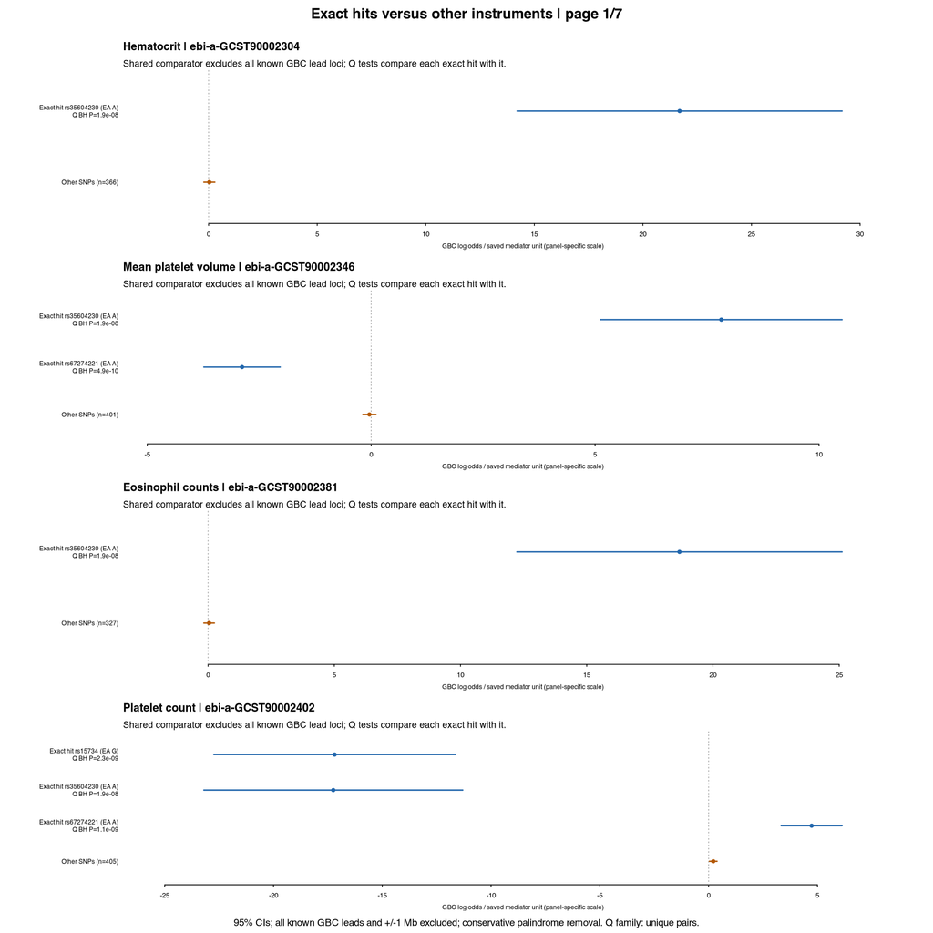

Exact-hit comparison

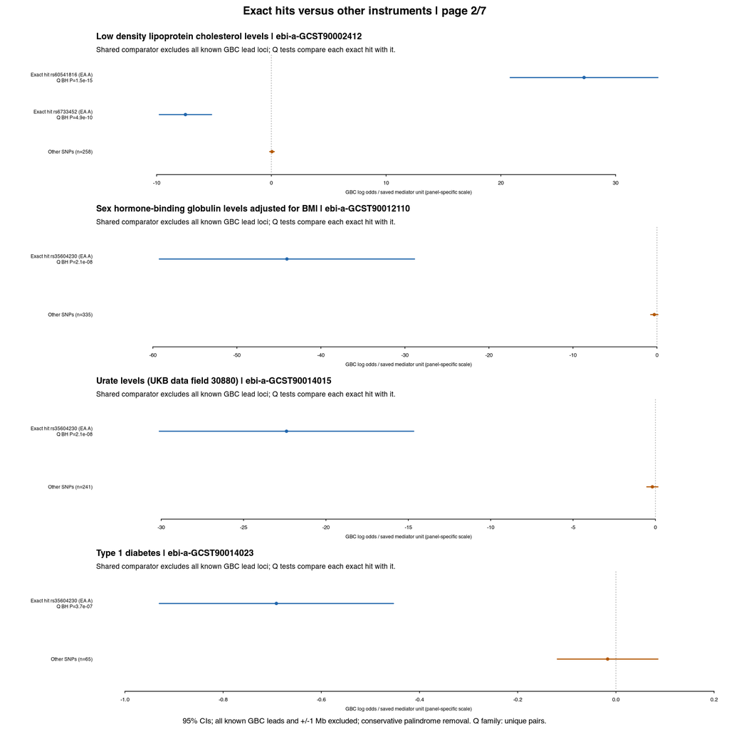

Exact-hit comparison

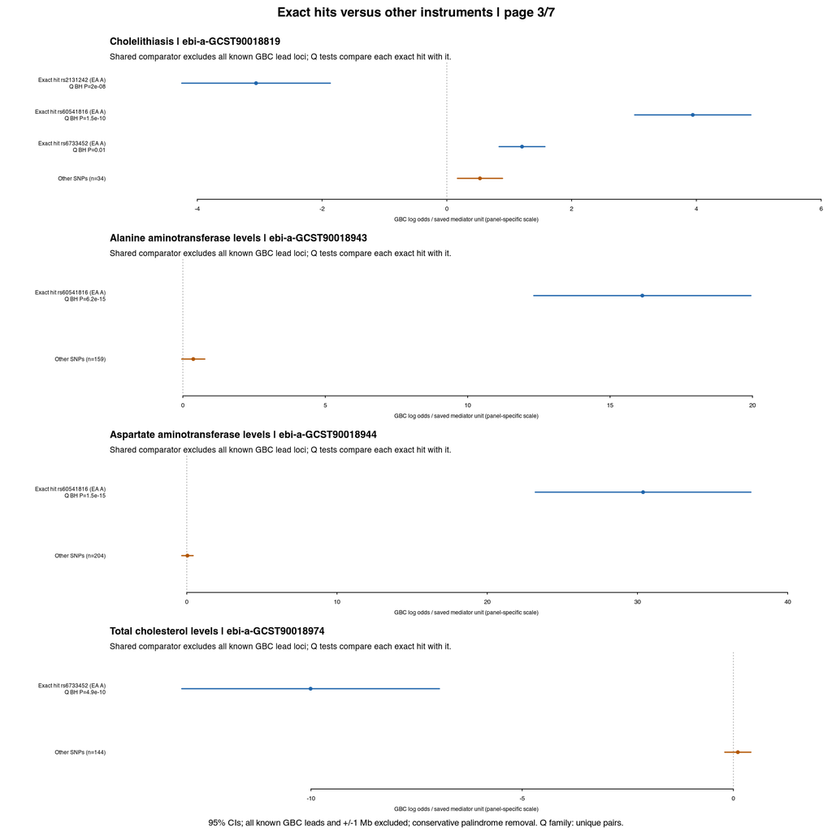

Exact-hit comparison

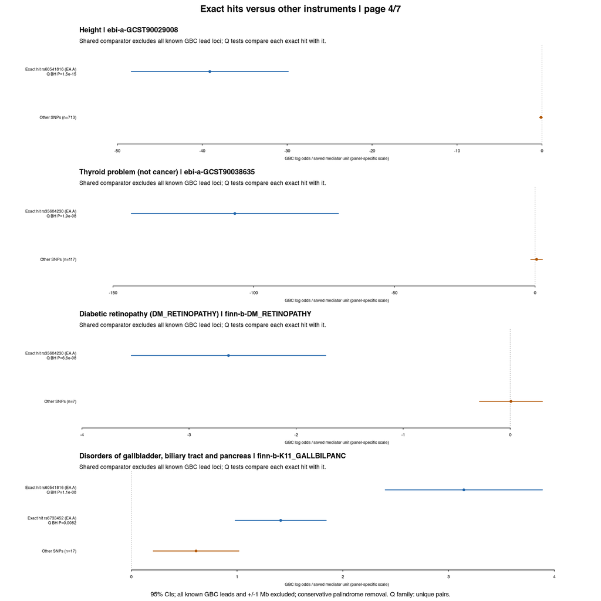

Exact-hit comparison

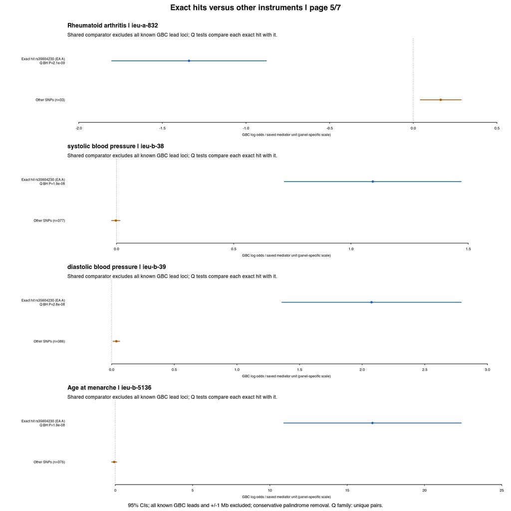

Exact-hit comparison

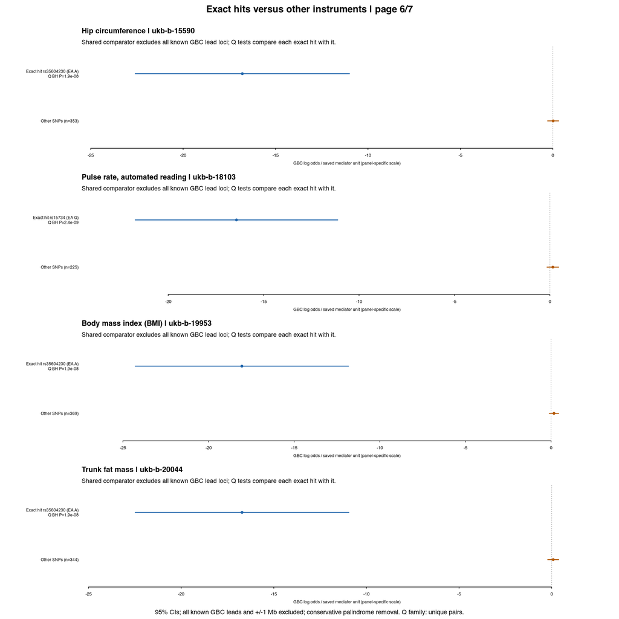

Exact-hit comparison

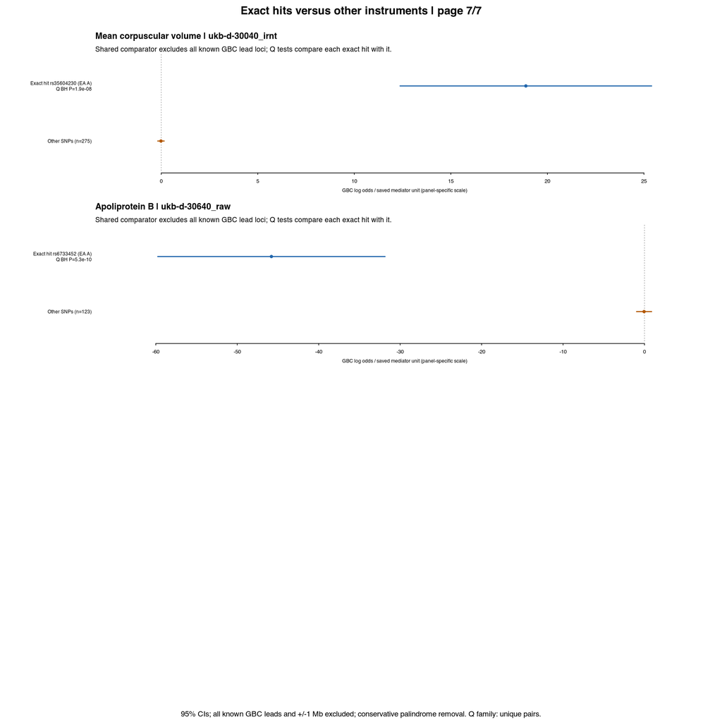

Exact-hit comparison

## Pooled mediator MR

Pooled MR uses the **same all-GBC-hit-excluded estimate as the shared comparator**. Each mediator contributes one pooled-family test, while its exact-hit comparisons contribute one Q test per retained SNP. A SNP excluded for one GBC hit cannot return through another hit’s complement.

| mediator | targets | excluded_before_matching | excluded_after_matching | n | method | estimate_CI | P | BH_P | minimum_F | reason |
| --- | --- | --- | --- | --- | --- | --- | --- | --- | --- | --- |
| Hematocrit | 1 | 7 | 7 | 366 | IVW (multiplicative random effects) | 0.0327 [-0.22, 0.286] | 0.8 | 0.95 | 29.8068 |  |
| Mean platelet volume | 2 | 11 | 10 | 401 | IVW (multiplicative random effects) | -0.0397 [-0.185, 0.106] | 0.59 | 0.92 | 30.0620 |  |
| Eosinophil counts | 1 | 7 | 8 | 327 | IVW (multiplicative random effects) | 0.0395 [-0.17, 0.249] | 0.71 | 0.95 | 29.8192 |  |
| Platelet count | 3 | 10 | 8 | 405 | IVW (multiplicative random effects) | 0.211 [0.035, 0.387] | 0.019 | 0.098 | 29.7766 |  |
| Low density lipoprotein cholesterol levels | 2 | 7 | 7 | 258 | IVW (multiplicative random effects) | 0.0543 [-0.149, 0.258] | 0.6 | 0.92 | 29.8601 |  |
| Sex hormone-binding globulin levels adjusted for BMI | 1 | 7 | 6 | 335 | IVW (multiplicative random effects) | -0.318 [-0.751, 0.115] | 0.15 | 0.55 | 21.7694 |  |
| Urate levels (UKB data field 30880) | 1 | 2 | 2 | 241 | IVW (multiplicative random effects) | -0.184 [-0.522, 0.154] | 0.29 | 0.74 | 29.7274 |  |
| Type 1 diabetes | 1 | 5 | 4 | 65 | IVW (multiplicative random effects) | -0.0168 [-0.119, 0.0857] | 0.75 | 0.95 | 29.8657 |  |
| Cholelithiasis | 3 | 7 | 6 | 34 | IVW (multiplicative random effects) | 0.532 [0.17, 0.893] | 0.0039 | 0.05 | 29.9836 |  |
| Alanine aminotransferase levels | 1 | 4 | 4 | 159 | IVW (multiplicative random effects) | 0.366 [-0.0383, 0.771] | 0.076 | 0.33 | 29.1600 |  |
| Aspartate aminotransferase levels | 1 | 7 | 5 | 204 | IVW (multiplicative random effects) | 0.0448 [-0.334, 0.424] | 0.82 | 0.95 | 29.0662 |  |
| Total cholesterol levels | 1 | 5 | 4 | 144 | IVW (multiplicative random effects) | 0.106 [-0.203, 0.415] | 0.5 | 0.92 | 29.0946 |  |
| Height | 1 | 7 | 7 | 713 | IVW (multiplicative random effects) | -0.118 [-0.287, 0.0507] | 0.17 | 0.55 | 23.8855 |  |
| Thyroid problem (not cancer) | 1 | 5 | 2 | 117 | IVW (multiplicative random effects) | 0.548 [-1.52, 2.62] | 0.6 | 0.92 | 28.6070 |  |
| Diabetic retinopathy (DM_RETINOPATHY) | 1 | 2 | 2 | 7 | IVW (multiplicative random effects) | 0.0066 [-0.287, 0.301] | 0.96 | 0.96 | 32.9114 |  |
| Disorders of gallbladder, biliary tract and pancreas | 2 | 6 | 6 | 17 | IVW (multiplicative random effects) | 0.612 [0.208, 1.02] | 0.003 | 0.05 | 30.7260 |  |
| Rheumatoid arthritis | 1 | 5 | 5 | 33 | IVW (multiplicative random effects) | 0.164 [0.0421, 0.286] | 0.0084 | 0.055 | 29.8366 |  |
| systolic blood pressure | 1 | 7 | 6 | 377 | IVW (multiplicative random effects) | -0.00278 [-0.0207, 0.0151] | 0.76 | 0.95 | 29.7205 |  |
| diastolic blood pressure | 1 | 6 | 6 | 386 | IVW (multiplicative random effects) | 0.0376 [0.0109, 0.0644] | 0.0058 | 0.05 | 29.7001 |  |
| Age at menarche | 1 | 5 | 5 | 375 | IVW (multiplicative random effects) | -0.0731 [-0.235, 0.0893] | 0.38 | 0.82 | 29.5211 |  |
| Hip circumference | 1 | 5 | 5 | 353 | IVW (multiplicative random effects) | 0.018 [-0.28, 0.316] | 0.91 | 0.95 | 29.7476 |  |
| Pulse rate, automated reading | 1 | 1 | 1 | 225 | IVW (multiplicative random effects) | 0.155 [-0.15, 0.46] | 0.32 | 0.76 | 29.8521 |  |
| Body mass index (BMI) | 1 | 5 | 5 | 369 | IVW (multiplicative random effects) | 0.17 [-0.105, 0.444] | 0.23 | 0.65 | 29.7607 |  |
| Trunk fat mass | 1 | 3 | 3 | 344 | IVW (multiplicative random effects) | 0.0821 [-0.212, 0.377] | 0.58 | 0.92 | 29.7632 |  |
| Mean corpuscular volume | 1 | 4 | 3 | 275 | IVW (multiplicative random effects) | -0.0126 [-0.18, 0.154] | 0.88 | 0.95 | 30.0744 |  |
| Apoliprotein B | 1 | 3 | 3 | 123 | IVW (multiplicative random effects) | -0.0487 [-0.975, 0.878] | 0.92 | 0.95 | 29.7876 |  |

Platelet-count candidate ebi-a-GCST90002402: n=405, estimate 0.211 [0.035, 0.387], nominal P=0.019 and pooled-family BH P=0.098.

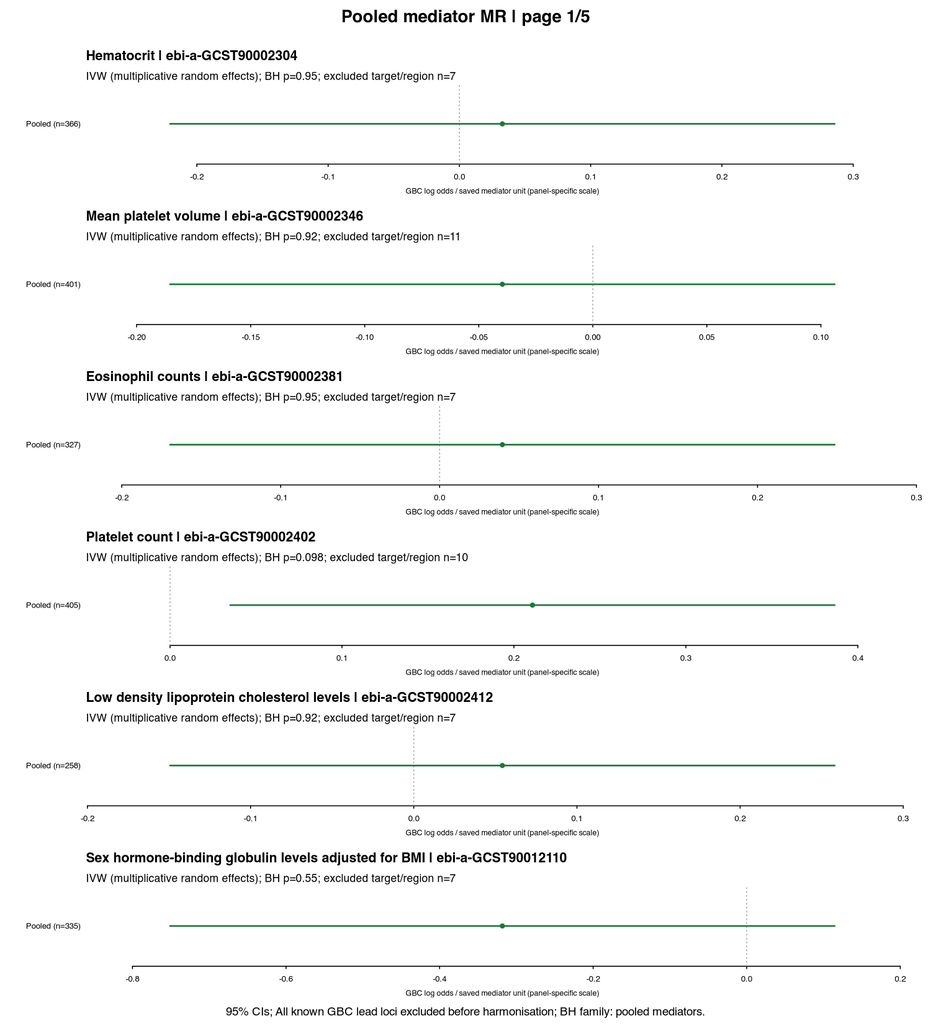

Pooled mediator MR

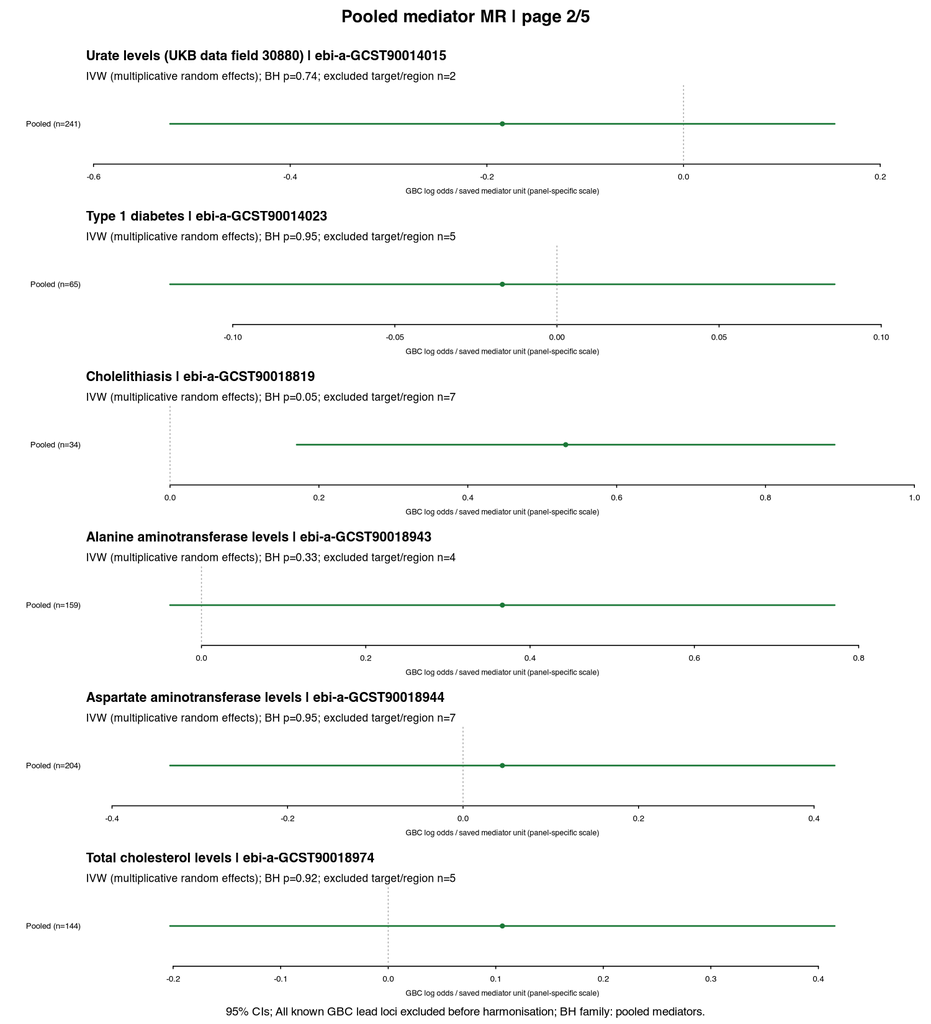

Pooled mediator MR

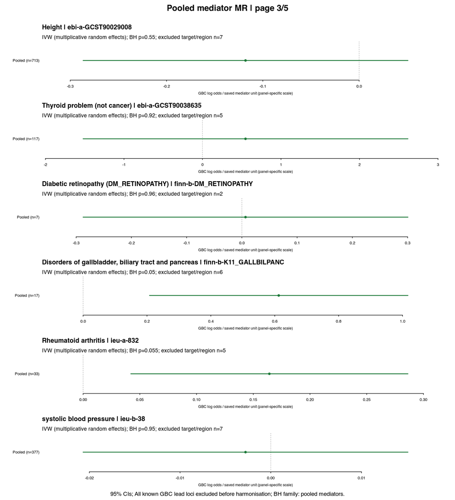

Pooled mediator MR

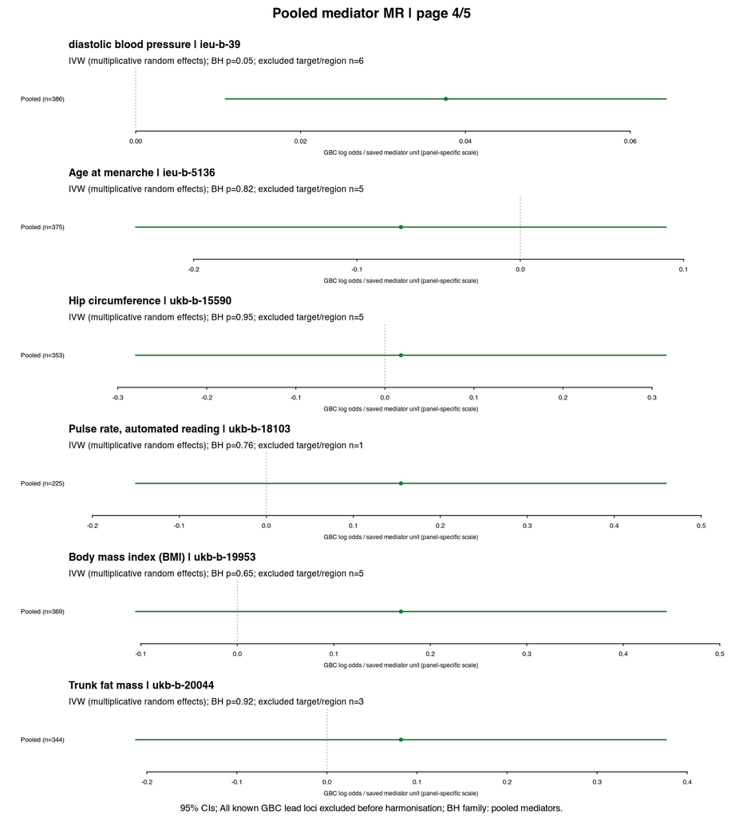

Pooled mediator MR

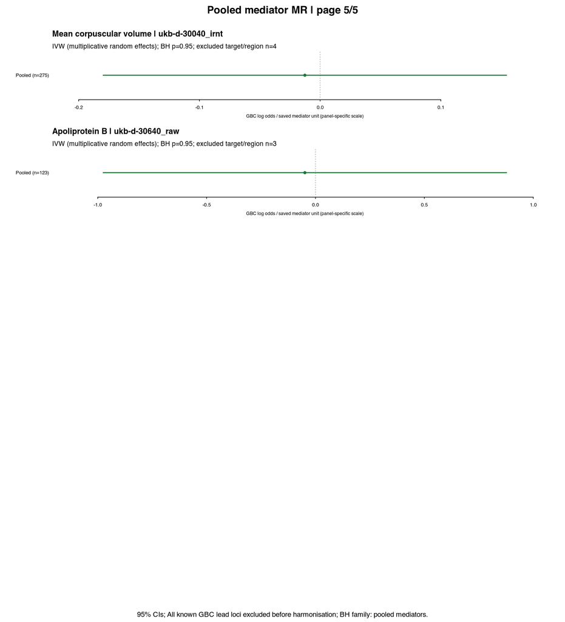

Pooled mediator MR

## Total, indirect and residual direct components

For each pair: **t = G→GBC**, **i = a × b**, **d = t − i**, where a is the exact G→mediator association and b is the mediator’s shared all-GBC-hit-excluded MR. Components share GBC log-odds units per recorded target effect allele. Opposing signs are retained; missing components are never zero. The pipeline validates t = i + d for every complete pair.

Approximate normal 95% CIs use a first-order delta method with zero covariances: Var(i) = b²Var(a) + a²Var(b), Var(d) = Var(t) + Var(i). General formulas add 2abCov(a,b) to Var(i), and subtract 2bCov(a,t) + 2aCov(b,t) from Var(d). Saved summary data do not identify these covariances. The supplement uses hypothetical equicorrelations −0.3, 0 and +0.3 among a, b and t; these are positive-definite matrices, not estimates of empirical covariance or sample overlap.

These are **model-based approximate components**, not identified causal natural effects. Binary traits, non-collapsibility, nonlinearity, population differences, LD and instrument validity limit causal interpretation. Indirect effects for separate correlated mediators must not be summed. No mediation percentage is reported.

| SNP | mediator | EA | total_CI | indirect_CI | residual_CI | indirect_P | indirect_BH_P | residual_P | residual_BH_P | reason |
| --- | --- | --- | --- | --- | --- | --- | --- | --- | --- | --- |
| rs35604230 | Hematocrit | A | 0.459 [0.301, 0.618] | 0.000693 [-0.00467, 0.00606] | 0.459 [0.3, 0.617] | 0.8 | 0.93 | 1.4e-08 | 1.9e-08 | NA |
| rs35604230 | Mean platelet volume | A | 0.459 [0.301, 0.618] | -0.00233 [-0.0109, 0.00623] | 0.462 [0.303, 0.62] | 0.59 | 0.83 | 1.2e-08 | 1.9e-08 | NA |
| rs67274221 | Mean platelet volume | A | 0.27 [0.19, 0.349] | 0.00371 [-0.00992, 0.0173] | 0.266 [0.185, 0.347] | 0.59 | 0.83 | 1.2e-10 | 4.9e-10 | NA |
| rs35604230 | Eosinophil counts | A | 0.459 [0.301, 0.618] | 0.000971 [-0.00418, 0.00612] | 0.458 [0.3, 0.617] | 0.71 | 0.93 | 1.5e-08 | 1.9e-08 | NA |
| rs15734 | Platelet count | G | -0.266 [-0.352, -0.18] | 0.00327 [0.000342, 0.00619] | -0.27 [-0.356, -0.184] | 0.029 | 0.094 | 8.3e-10 | 2.3e-09 | NA |
| rs35604230 | Platelet count | A | 0.459 [0.301, 0.618] | -0.00561 [-0.0105, -0.000731] | 0.465 [0.306, 0.623] | 0.024 | 0.089 | 9e-09 | 1.9e-08 | NA |
| rs67274221 | Platelet count | A | 0.27 [0.19, 0.349] | 0.012 [0.00196, 0.0221] | 0.258 [0.177, 0.338] | 0.019 | 0.079 | 3.3e-10 | 1.1e-09 | NA |
| rs60541816 | Low density lipoprotein cholesterol levels | A | -0.544 [-0.672, -0.415] | -0.00108 [-0.00516, 0.00299] | -0.543 [-0.671, -0.414] | 0.6 | 0.83 | 1.3e-16 | 1.5e-15 | NA |
| rs6733452 | Low density lipoprotein cholesterol levels | A | 0.841 [0.585, 1.1] | -0.0061 [-0.029, 0.0168] | 0.847 [0.59, 1.1] | 0.6 | 0.83 | 1.1e-10 | 4.9e-10 | NA |
| rs35604230 | Sex hormone-binding globulin levels adjusted for BMI | A | 0.459 [0.301, 0.618] | 0.00332 [-0.00127, 0.00791] | 0.456 [0.297, 0.614] | 0.16 | 0.43 | 1.7e-08 | 2.2e-08 | NA |
| rs35604230 | Urate levels (UKB data field 30880) | A | 0.459 [0.301, 0.618] | 0.00378 [-0.00323, 0.0108] | 0.455 [0.297, 0.614] | 0.29 | 0.64 | 1.8e-08 | 2.2e-08 | NA |
| rs35604230 | Type 1 diabetes | A | 0.459 [0.301, 0.618] | 0.0112 [-0.0569, 0.0793] | 0.448 [0.276, 0.62] | 0.75 | 0.93 | 3.5e-07 | 3.7e-07 | NA |
| rs2131242 | Cholelithiasis | A | -0.348 [-0.483, -0.213] | 0.0605 [0.0167, 0.104] | -0.408 [-0.551, -0.266] | 0.0067 | 0.044 | 1.9e-08 | 2.2e-08 | NA |
| rs60541816 | Cholelithiasis | A | -0.544 [-0.672, -0.415] | -0.0733 [-0.124, -0.0222] | -0.47 [-0.609, -0.332] | 0.005 | 0.041 | 2.6e-11 | 1.7e-10 | NA |
| rs6733452 | Cholelithiasis | A | 0.841 [0.585, 1.1] | 0.371 [0.116, 0.625] | 0.47 [0.109, 0.831] | 0.0043 | 0.041 | 0.011 | 0.011 | NA |
| rs60541816 | Alanine aminotransferase levels | A | -0.544 [-0.672, -0.415] | -0.0123 [-0.0261, 0.00141] | -0.531 [-0.661, -0.402] | 0.079 | 0.24 | 7.6e-16 | 6.3e-15 | NA |
| rs60541816 | Aspartate aminotransferase levels | A | -0.544 [-0.672, -0.415] | -0.000802 [-0.00758, 0.00598] | -0.543 [-0.672, -0.414] | 0.82 | 0.93 | 1.3e-16 | 1.5e-15 | NA |
| rs6733452 | Total cholesterol levels | A | 0.841 [0.585, 1.1] | -0.00892 [-0.035, 0.0171] | 0.85 [0.592, 1.11] | 0.5 | 0.83 | 1e-10 | 4.9e-10 | NA |
| rs60541816 | Height | A | -0.544 [-0.672, -0.415] | -0.00164 [-0.00404, 0.000762] | -0.542 [-0.671, -0.414] | 0.18 | 0.46 | 1.4e-16 | 1.5e-15 | NA |
| rs35604230 | Thyroid problem (not cancer) | A | 0.459 [0.301, 0.618] | -0.00236 [-0.0113, 0.00658] | 0.462 [0.303, 0.62] | 0.6 | 0.83 | 1.2e-08 | 1.9e-08 | NA |
| rs35604230 | Diabetic retinopathy (DM_RETINOPATHY) | A | 0.459 [0.301, 0.618] | -0.00115 [-0.0525, 0.0502] | 0.46 [0.294, 0.627] | 0.96 | 0.96 | 6e-08 | 6.6e-08 | NA |
| rs60541816 | Disorders of gallbladder, biliary tract and pancreas | A | -0.544 [-0.672, -0.415] | -0.106 [-0.178, -0.0334] | -0.438 [-0.585, -0.29] | 0.0042 | 0.041 | 6e-09 | 1.4e-08 | NA |
| rs6733452 | Disorders of gallbladder, biliary tract and pancreas | A | 0.841 [0.585, 1.1] | 0.364 [0.121, 0.608] | 0.476 [0.122, 0.83] | 0.0034 | 0.041 | 0.0083 | 0.0086 | NA |
| rs35604230 | Rheumatoid arthritis | A | 0.459 [0.301, 0.618] | -0.0562 [-0.099, -0.0134] | 0.515 [0.351, 0.68] | 0.01 | 0.047 | 7.4e-10 | 2.2e-09 | NA |
| rs35604230 | systolic blood pressure | A | 0.459 [0.301, 0.618] | -0.00117 [-0.0087, 0.00636] | 0.46 [0.302, 0.619] | 0.76 | 0.93 | 1.3e-08 | 1.9e-08 | NA |
| rs35604230 | diastolic blood pressure | A | 0.459 [0.301, 0.618] | 0.00833 [0.00205, 0.0146] | 0.451 [0.292, 0.609] | 0.0093 | 0.047 | 2.5e-08 | 2.8e-08 | NA |
| rs35604230 | Age at menarche | A | 0.459 [0.301, 0.618] | -0.00202 [-0.00655, 0.00251] | 0.461 [0.303, 0.62] | 0.38 | 0.74 | 1.2e-08 | 1.9e-08 | NA |
| rs35604230 | Hip circumference | A | 0.459 [0.301, 0.618] | -0.000493 [-0.00864, 0.00765] | 0.46 [0.301, 0.618] | 0.91 | 0.95 | 1.3e-08 | 1.9e-08 | NA |
| rs15734 | Pulse rate, automated reading | G | -0.266 [-0.352, -0.18] | 0.00251 [-0.0025, 0.00752] | -0.269 [-0.355, -0.183] | 0.33 | 0.67 | 9.6e-10 | 2.4e-09 | NA |
| rs35604230 | Body mass index (BMI) | A | 0.459 [0.301, 0.618] | -0.00431 [-0.0114, 0.00276] | 0.464 [0.305, 0.622] | 0.23 | 0.55 | 1e-08 | 1.9e-08 | NA |
| rs35604230 | Trunk fat mass | A | 0.459 [0.301, 0.618] | -0.00226 [-0.0104, 0.00585] | 0.461 [0.303, 0.62] | 0.59 | 0.83 | 1.2e-08 | 1.9e-08 | NA |
| rs35604230 | Mean corpuscular volume | A | 0.459 [0.301, 0.618] | -0.000307 [-0.00437, 0.00376] | 0.46 [0.301, 0.618] | 0.88 | 0.95 | 1.3e-08 | 1.9e-08 | NA |
| rs6733452 | Apoliprotein B | A | 0.841 [0.585, 1.1] | 0.000894 [-0.0161, 0.0179] | 0.84 [0.583, 1.1] | 0.92 | 0.95 | 1.4e-10 | 5.3e-10 | NA |

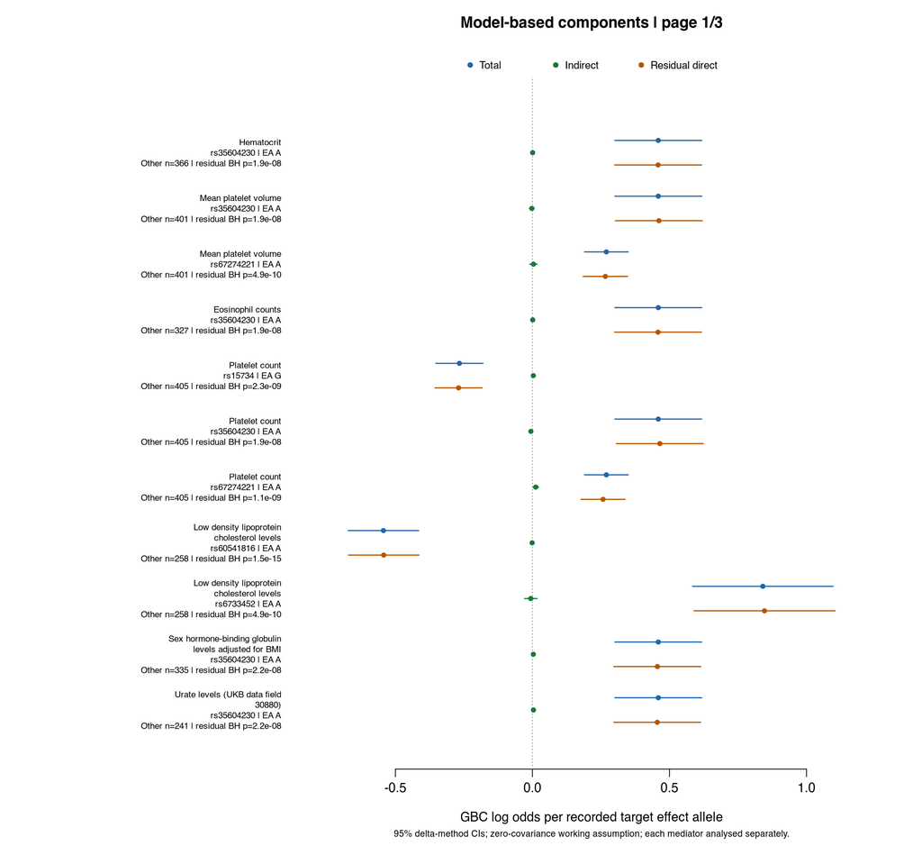

Effect decomposition

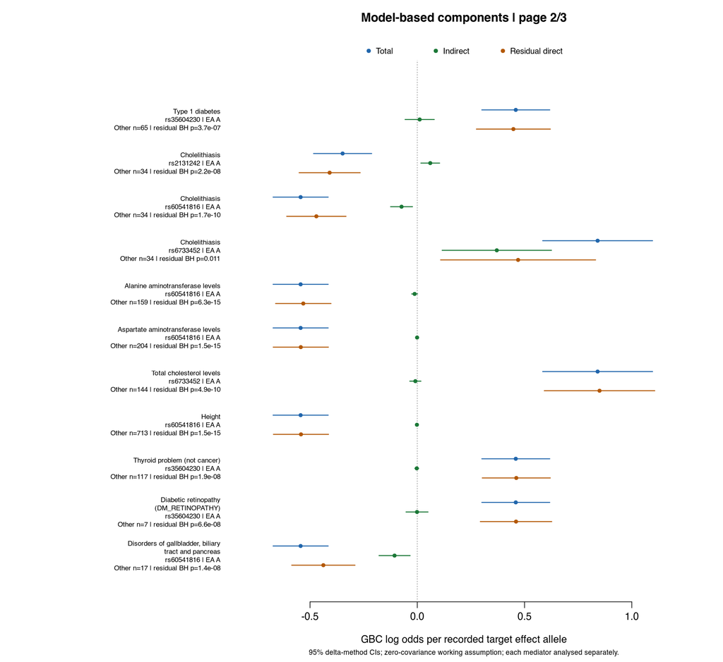

Effect decomposition

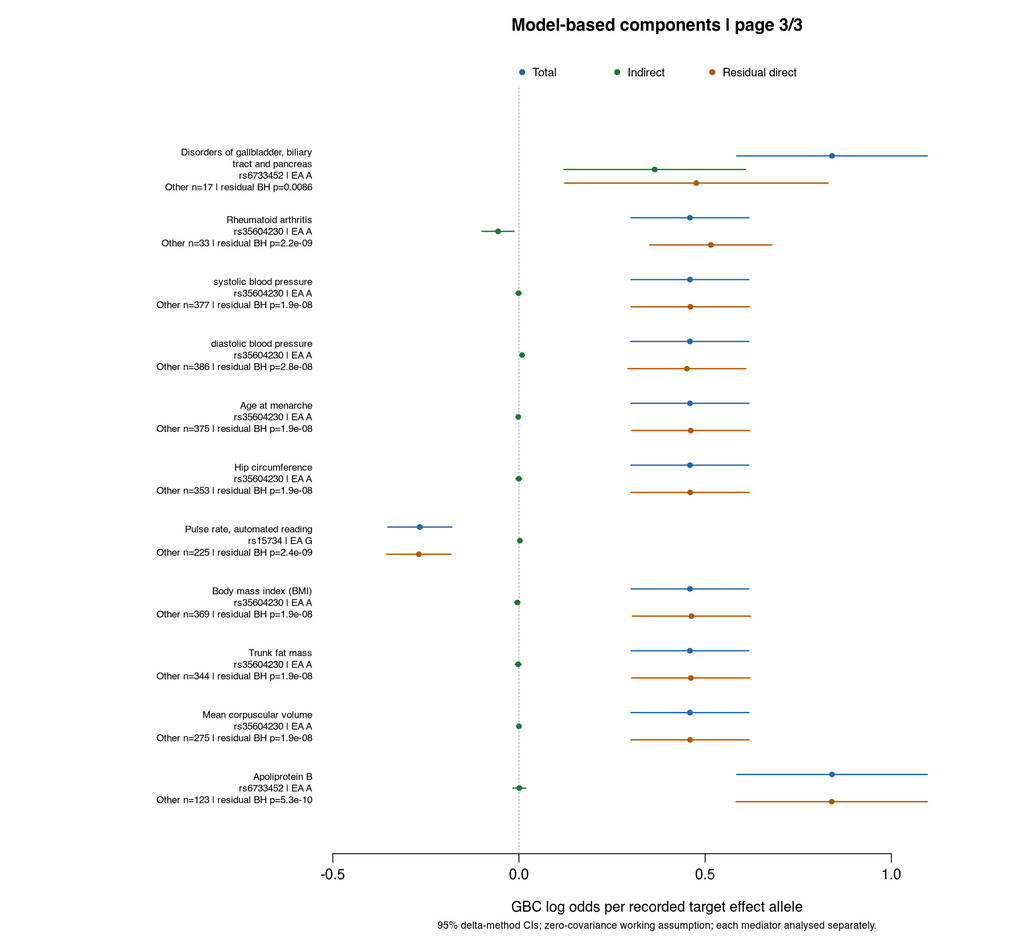

Effect decomposition

## Interpretation and testing families

Q indicates incompatibility with the common-effect/full-mediation model under its assumptions. Invalid target/comparator instruments, residual LD or population/scale differences may explain incompatibility; Q does not uniquely locate a direct pathway. A non-significant comparison means **no detected heterogeneity; mediation unresolved**. It proves neither mediation nor equivalence. Comparator precision and instrument strength are recorded in the CSV.

There are 33 BH-incompatible pairs among 33 tested unique pairs in the retained inventory of 33 pairs. Each named family separately applies BH at 0.05 to its available tests; this does not claim global control across separate families. Indirect/residual tests use approximate normal delta-method intervals. The two window/MHC sensitivity scenarios each use their own separately named 33-pair BH family; covariance scenarios describe approximate interval sensitivity. Per-SNP counts describe pair tests and are not additional SNP-level hypothesis tests.

| family | inventory | tested | unavailable | nominal_below_005 | bh_below_005 |
| --- | --- | --- | --- | --- | --- |
| unique_pair_heterogeneity | 33 | 33 | 0 | 33 | 33 |
| pooled_mediator_mr | 26 | 26 | 0 | 5 | 0 |
| unique_pair_indirect_component | 33 | 33 | 0 | 10 | 7 |
| unique_pair_residual_component | 33 | 33 | 0 | 33 | 33 |
| sensitivity_pair_heterogeneity_2mb | 33 | 33 | 0 | 33 | 33 |
| sensitivity_pair_heterogeneity_2mb_mhc | 33 | 33 | 0 | 33 | 33 |

| target_snp | pairs | tested | unavailable | incompatible_bh | no_detected_heterogeneity |
| --- | --- | --- | --- | --- | --- |
| rs35604230 | 17 | 17 | 0 | 17 | 0 |
| rs67274221 | 2 | 2 | 0 | 2 | 0 |
| rs15734 | 2 | 2 | 0 | 2 | 0 |
| rs60541816 | 6 | 6 | 0 | 6 | 0 |
| rs6733452 | 5 | 5 | 0 | 5 | 0 |
| rs2131242 | 1 | 1 | 0 | 1 | 0 |

Every row is traceable by mediator ID and SNP to the saved exact-association export, retained comparator SNP list, exclusion counts and explicit missingness reasons. All empirical pairs happen to be usable under the primary policy. The unavailable example below is deliberately labelled as an illustrative missing-comparator scenario, excluded from empirical counts.

| example | source_kind | mediator_id | target_snp | interpretation | precision | reason |
| --- | --- | --- | --- | --- | --- | --- |
| Available | Saved empirical comparison | ebi-a-GCST90002304 | rs35604230 | Incompatible with common-effect model (BH < 0.05) | Comparator CI includes zero |  |
| Imprecise comparator | Saved empirical comparison | ebi-a-GCST90002304 | rs35604230 | Incompatible with common-effect model (BH < 0.05) | Comparator CI includes zero |  |
| Incompatible | Saved empirical comparison | ebi-a-GCST90002304 | rs35604230 | Incompatible with common-effect model (BH < 0.05) | Comparator CI includes zero |  |
| Illustrative unavailable comparator | Validation scenario: remove comparator; not an empirical result | ebi-a-GCST90002304 | rs35604230 | Unavailable comparison | Comparator unavailable | Illustrative validation only: comparator association deliberately omitted |

Synthetic tests validate unavailable inputs, allele reversals, complete mediation, residual effects, opposing pathways, increasing uncertainty and covariance sensitivities.

## Downloads and reproduction

- Comparison PDF / first PNG page
- Decomposition PDF / first PNG page
- Pooled MR PDF
- Comparison CSV, pooled MR CSV, decomposition CSV
- Representative traceable relationships
- Legacy pooled diagnostics, complement-union bug counts
- Window/MHC sensitivity, covariance sensitivity
- Original-hit inventory, saved exact associations
- Testing families, per-SNP summary
- Provenance, package versions, session information

From the repository root, using the existing local `data/gbc_phewas_results-g2.Rdata`:

```bash
Rscript scripts/run-offline-g2.R
quarto render scripts/phewas-followup-g2.qmd --no-cache
Rscript tests/run-tests.R
```

A compact lossless subset of the required saved associations is included in `data/offline-g2-inputs.rds`. The source checksums and extraction counts are in Snapshot provenance. No new empirical data were acquired. For a checkout without the original Rdata:

```bash
Rscript scripts/run-offline-g2.R data/offline-g2-inputs.rds
GBC_G2_INPUT=data/offline-g2-inputs.rds quarto render scripts/phewas-followup-g2.qmd --no-cache
```

No remote installation or data access is needed. The older G1 workflow is unchanged. Each render recomputes all tables/figures and bypasses old caches.

| input | md5 | retained_pairs | mediators | targets | original_lead_snps | policy |
| --- | --- | --- | --- | --- | --- | --- |
| data/offline-g2-inputs.rds | 3140a85d4192c4fdd13e14a153a1931f | 33 | 26 | 6 | 8 | Exact SNP; shared mediator comparator excluding all known GBC leads and +/-1 Mb; all palindromes removed; no remote access or result cache |

| package | version |
| --- | --- |
| R | 4.6.1 |
| TwoSampleMR | 0.7.6 |
| ieugwasr | 1.1.0.9000 |
| knitr | 1.51 |
| rmarkdown | 2.31 |